# PCA on a car features dataset

Jérémy GAMANGA

## Load data

```r
cars <- read.csv("cars-2004.csv", header=TRUE)
head(cars)
```

```
##                         Retail Dealer Engine Cylinders Horsepower CityMPG
## Acura 3.5 RL             43755  39014    3.5         6        225      18
## Acura 3.5 RL Navigation  46100  41100    3.5         6        225      18
## Acura MDX                36945  33337    3.5         6        265      17
## Acura NSX S              89765  79978    3.2         6        290      17
## Acura RSX                23820  21761    2.0         4        200      24
## Acura TL                 33195  30299    3.2         6        270      20
##                         HighwayMPG Weight Wheelbase Length Width
## Acura 3.5 RL                    24   3880       115    197    72
## Acura 3.5 RL Navigation         24   3893       115    197    72
## Acura MDX                       23   4451       106    189    77
## Acura NSX S                     24   3153       100    174    71
## Acura RSX                       31   2778       101    172    68
## Acura TL                        28   3575       108    186    72
```

## Convertion from us system unit to metric system unit

```r
mpg2kml <- 0.42514 # miles per gallon -> kilometer per liter
usd2eur <- 0.945 # US dollars -> Euro
lb2kg <- 0.4535923 # pound -> kilogram
inch2cm <- 2.54 # inch -> centimeter

cars$Retail <-  usd2eur*cars$Retail
cars$Dealer <-  usd2eur*cars$Dealer

cars$CityMPG <- mpg2kml*cars$CityMPG
cars$HighwayMPG <- mpg2kml*cars$HighwayMPG

cars$Weight <- lb2kg * cars$Weight

cars$Wheelbase <- lb2kg * cars$Wheelbase
cars$Length <- inch2cm * cars$Length
cars$Width <- inch2cm * cars$Width
```

## Correlation between feature

```r
cor(cars)
```

```
##                Retail     Dealer     Engine  Cylinders Horsepower    CityMPG
## Retail      1.0000000  0.9991270  0.5994160  0.6543540  0.8350735 -0.4852132
## Dealer      0.9991270  1.0000000  0.5936250  0.6508783  0.8326501 -0.4819796
## Engine      0.5994160  0.5936250  1.0000000  0.9114409  0.7786167 -0.7053772
## Cylinders   0.6543540  0.6508783  0.9114409  1.0000000  0.7911436 -0.6705137
## Horsepower  0.8350735  0.8326501  0.7786167  0.7911436  1.0000000 -0.6718006
## CityMPG    -0.4852132 -0.4819796 -0.7053772 -0.6705137 -0.6718006  1.0000000
## HighwayMPG -0.4692910 -0.4658793 -0.7074081 -0.6641886 -0.6504680  0.9411187
## Weight      0.4759939  0.4719626  0.8116405  0.7311810  0.6310581 -0.7361656
## Wheelbase   0.2033541  0.2033607  0.6314698  0.5526925  0.3966260 -0.4811264
## Length      0.2095530  0.2068781  0.6245811  0.5463634  0.3814257 -0.4675862
## Width       0.3130027  0.3057856  0.7260991  0.6188343  0.4994469 -0.5868873
##            HighwayMPG     Weight  Wheelbase     Length      Width
## Retail     -0.4692910  0.4759939  0.2033541  0.2095530  0.3130027
## Dealer     -0.4658793  0.4719626  0.2033607  0.2068781  0.3057856
## Engine     -0.7074081  0.8116405  0.6314698  0.6245811  0.7260991
## Cylinders  -0.6641886  0.7311810  0.5526925  0.5463634  0.6188343
## Horsepower -0.6504680  0.6310581  0.3966260  0.3814257  0.4994469
## CityMPG     0.9411187 -0.7361656 -0.4811264 -0.4675862 -0.5868873
## HighwayMPG  1.0000000 -0.7886069 -0.4546093 -0.3891091 -0.5827406
## Weight     -0.7886069  1.0000000  0.7509153  0.6528933  0.8066275
## Wheelbase  -0.4546093  0.7509153  1.0000000  0.8665289  0.7568386
## Length     -0.3891091  0.6528933  0.8665289  1.0000000  0.7513574
## Width      -0.5827406  0.8066275  0.7568386  0.7513574  1.0000000
```

We can see from the correlation matrix that:

- Retail and Dealer are highly correlated with each other, with a correlation coefficient of 0.999, which is quite consistent, since the selling price (dealer) is based on the recommended price (retail).
- Horsepower correlates very well with Retail and Dealer, with correlation coefficients of 0.835 and 0.832 respectively, showing that the most powerful cars are the most expensive.
- CityMPG and HighWayMPG are strongly correlated with each other, with a correlation coefficient of 0.94, indicating that consumption in the city is strongly linked to that on freeways.
- CityMPG and HighWayMPG are negatively correlated with Weight, which is quite consistent with the fact that the lighter a car is, the less it consumes.

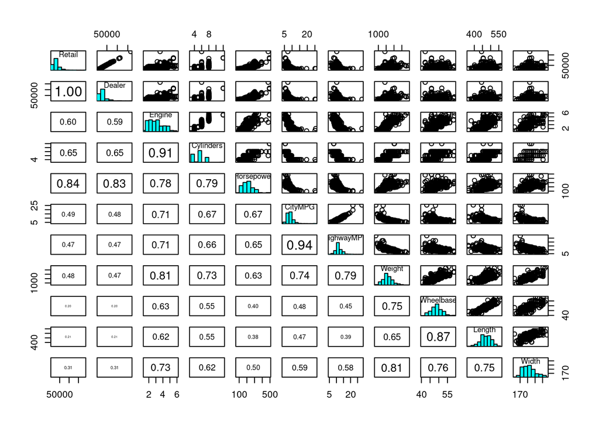

```r
?pairs

panel.hist <- function(x, ...)
{
    usr <- par("usr")
    par(usr = c(usr[1:2], 0, 1.5) )
    h <- hist(x, plot = FALSE)
    breaks <- h$breaks; nB <- length(breaks)
    y <- h$counts; y <- y/max(y)/1.1
    rect(breaks[-nB], 0, breaks[-1], y, col = "cyan", ...)
}
panel.cor <- function(x, y, digits = 2, prefix = "", cex.cor, ...)
{
    par(usr = c(0, 1, 0, 1))
    r <- abs(cor(x, y))
    txt <- format(c(r, 0.123456789), digits = digits)[1]
    txt <- paste0(prefix, txt)
    if(missing(cex.cor)) cex.cor <- 0.8/strwidth(txt)
    text(0.5, 0.5, txt, cex = cex.cor * r)
}
par(mar=c(4,4,2,1)-.5)
pairs(cars, diag.panel=panel.hist,
      lower.panel = panel.cor)
```

Thus, this plot confirms several observations made in the correlation analysis and also provides further information concerning the distribution of these variables across the histograms.

## Principal component analysis using stats package

```r
PCA.prcomp <- prcomp(cars, scale=TRUE)
summary(PCA.prcomp)
```

```
## Importance of components:
##                           PC1    PC2     PC3     PC4     PC5     PC6     PC7
## Standard deviation     2.6655 1.3726 0.92181 0.59751 0.52482 0.44491 0.37486
## Proportion of Variance 0.6459 0.1713 0.07725 0.03246 0.02504 0.01799 0.01277
## Cumulative Proportion  0.6459 0.8171 0.89439 0.92685 0.95189 0.96988 0.98266
##                            PC8     PC9    PC10    PC11
## Standard deviation     0.29434 0.25766 0.19229 0.02811
## Proportion of Variance 0.00788 0.00604 0.00336 0.00007
## Cumulative Proportion  0.99053 0.99657 0.99993 1.00000
```

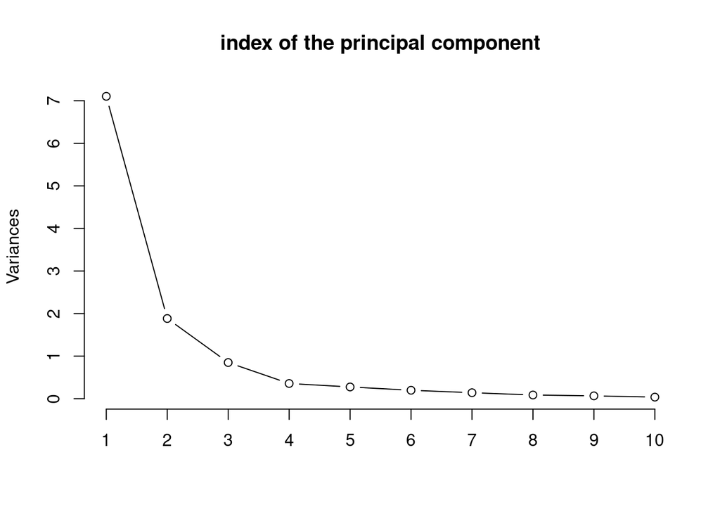

```r
plot(PCA.prcomp, type="l", main ="index of the principal component")
```

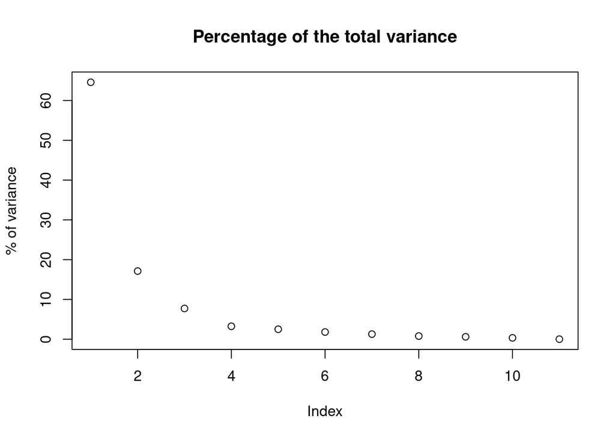

```r
plot(PCA.prcomp$sdev^2/sum(PCA.prcomp$sdev^2)*100, ylab ="% of variance", main="Percentage of the total variance")
```

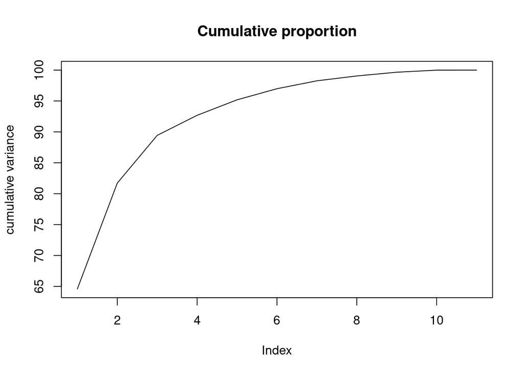

```r
cumul.sum <- cumsum(PCA.prcomp$sdev^2/sum(PCA.prcomp$sdev^2)*100)
plot(cumul.sum, type="l", ylab ="cumulative variance", main="Cumulative proportion")
```

The rule of thumb is to take the components that reach a cumulative explained variance of at least 0.75. In our case, it’s sufficient to take the first two components. Indeed, the first two components have an explained variance of 65% and 17% respectively.

## Analysis

```r
matrix.change.basis <- PCA.prcomp$rotation
print(matrix.change.basis)
```

```
##                   PC1          PC2         PC3         PC4         PC5
## Retail     -0.2637504 -0.468508698 -0.25497414  0.27988372 -0.04974519
## Dealer     -0.2623186 -0.470146585 -0.25725039  0.28771958 -0.03681996
## Engine     -0.3470805  0.015347186 -0.04719422 -0.52537085 -0.05199547
## Cylinders  -0.3341888 -0.078032011 -0.08144926 -0.63979956  0.12572880
## Horsepower -0.3186023 -0.292213476 -0.07638087 -0.05834309  0.11991697
## CityMPG     0.3104817  0.003365936 -0.53506296 -0.18627557 -0.32572837
## HighwayMPG  0.3065886  0.010964460 -0.59899766 -0.12574440 -0.03974688
## Weight     -0.3363294  0.167463572  0.11221865  0.11954611 -0.39721698
## Wheelbase  -0.2662100  0.418177107 -0.26445345  0.22070397  0.22487841
## Length     -0.2567902  0.408411381 -0.34470795  0.16849408  0.45631524
## Width      -0.2960546  0.312891350 -0.08759176  0.09065658 -0.66258913
##                     PC6         PC7          PC8          PC9         PC10
## Retail     -0.032492780  0.22241966  0.051733338 -0.090697742  0.024222804
## Dealer     -0.048557764  0.21944375  0.066924964 -0.086684420  0.028296680
## Engine     -0.005366507  0.05172424 -0.358461569 -0.683332423 -0.010997289
## Cylinders  -0.092893743  0.23997429  0.423251772  0.452827436 -0.004140785
## Horsepower  0.208117703 -0.81352906 -0.180257941  0.227458995  0.010574748
## CityMPG    -0.248202294 -0.09254946 -0.166248559  0.119762499  0.603612624
## HighwayMPG  0.081731932 -0.05687409  0.004478466 -0.010063971 -0.720867745
## Weight     -0.541582756  0.03774491 -0.417049636  0.335965459 -0.304350252
## Wheelbase  -0.449967732 -0.29947371  0.458409091 -0.284378470  0.041367733
## Length      0.314058641  0.27751645 -0.406364770  0.228686539  0.136883007
## Width       0.530956852 -0.01888721  0.275417442 -0.006361882  0.035872189
##                     PC11
## Retail      0.7092944127
## Dealer     -0.7046473100
## Engine     -0.0095506165
## Cylinders   0.0038579751
## Horsepower -0.0010013109
## CityMPG     0.0004696922
## HighwayMPG -0.0026644793
## Weight     -0.0020139958
## Wheelbase   0.0129305351
## Length     -0.0025480564
## Width      -0.0090242027
```

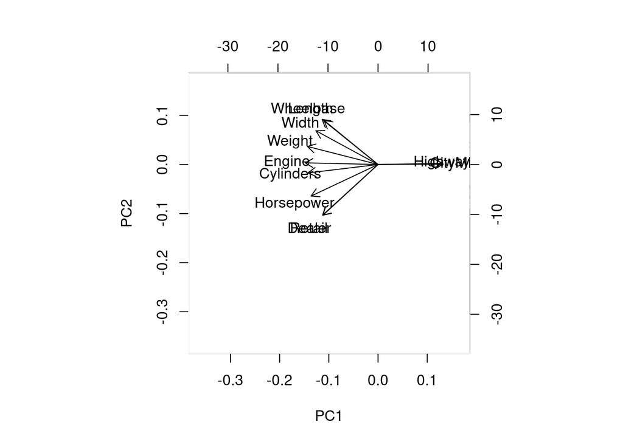

```r
biplot(PCA.prcomp, col=c("white", "black"), choices = c(1,2))
```

The principal component is positively correlated with CityMPG and HighwayMPG. It is negatively correlated with Retail, Dealer, Engine, Cylinders, Horsepower, Weight, Wheelbase, Length, Width. Apart from these sign differences, the absolute values of each coefficient remain of the same order of magnitude. This first component therefore seems to highlight a negative correlation between car consumption and the rest of the variables. It divides cars into two groups: those that consume little fuel, are inexpensive and small, and those that are relatively expensive, have powerful engines and are large. The first group seems to be city cars that emphasize efficiency and affordability (cheap to buy and run). The second group seems to refer to cars purchased outside this pragmatic logic. For example, sports cars, which are high-consumption vehicles with powerful engines, or SUVs, which are large and have high fuel consumption. Both come at a high price, and are more in line with personal taste than cost-cutting logic.

The second principal component is uncorrelated with the CityMPG and HighwayMPG variables. It is also uncorrelated with the Engine and Cylinders variables. It is therefore the principal component that fully explains these variables. If we look at these 4 variables, we can see that they reflect the car’s fuel consumption and range in conventional use, i.e. for city and freeway travel. This first component could represent cars that consume little and are inexpensive: city cars or entry-level cars.

the second component is negatively correlated with Retail, Dealer and Horsepower. It is positively correlated with Weight, Wheelbase, Length and Width. Given that these variables have the same sign in the main component, the second component induces a negative correlation between these two groups. The Retail, Dealer, Horsepower group, which carries information on the price of the car (a higher horsepower rating leads to a more expensive vehicle registration document). The Weight, Wheelbase, Length and Width group, which provides information on car size.

This second component seems to separate expensive, powerful cars from larger ones. Bearing in mind that we’re in the process of separating cars that are already relatively expensive (as the first component has already made an initial separation by price), we can no longer speak of entry-level cars here. We are therefore separating cars into two groups: those that are very expensive and powerful, such as sports cars or luxury cars, and cars that are mainly large without being excessively expensive, such as SUVs or MPVs. SUVs or minivans.

Let’s give an ID to each car.

```r
ID <-seq(1, nrow(cars), 1)
cars$ID <- ID
```

Let’s display all the data respect to PC1 and PC2. Every star is a data point and only the one corresponding to the Porsche 911 GT2 get its label displayed. The red vectors correspond to the features representations in the space.

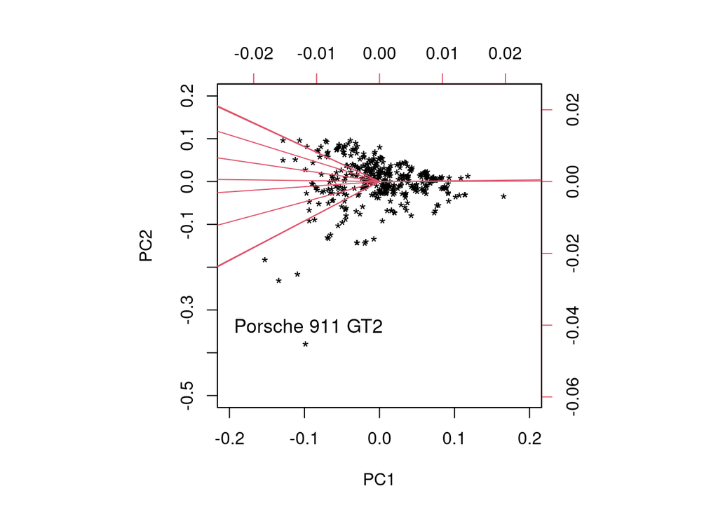

```r
label <- rep("*", nrow(cars))
label[cars["Porsche 911 GT2","ID"]] <- " Porsche 911 GT2\n*"
biplot(PCA.prcomp, expand=1000,cex=c(1.1,1), xlabs=label,ylim=c(-0.5,0.2), xlim=c(-0.2,0.2))
```

We can see, for example, that the Porche 991 GT2 has a negative PC2 component, which is consistent with the fact that it is very expensive, very powerful and small in size (compared to an SUV).

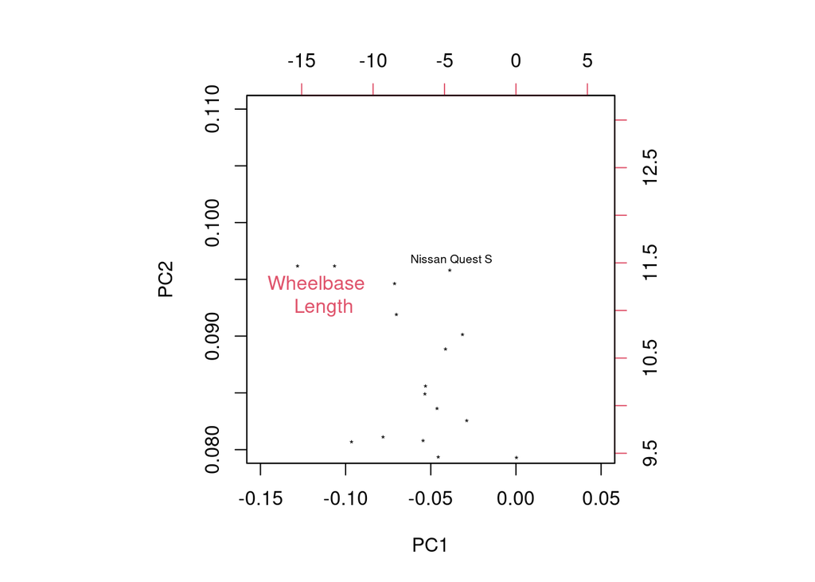

```r
label <- rep("*", nrow(cars))
label[cars["Nissan Quest S","ID"]] <- " Nissan Quest S\n*"
biplot(PCA.prcomp, ylim=c(0.08,0.11), xlim=c(-0.15,0.05), cex= c(0.6, 1),  xlabs=label)
```

We can see, for example, that the Nissan Quest S (it’s an MPV) has a positive PC2 component, which is consistent with the fact that it’s large and not particularly powerful, and has a low knock compared with sports cars or luxury cars.

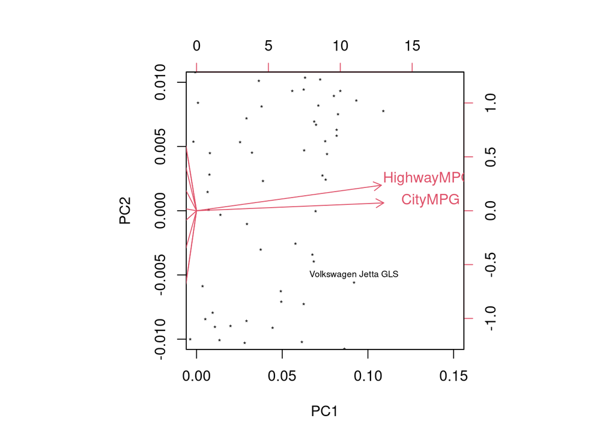

```r
label <- rep("*", nrow(cars))
label[cars["Volkswagen Jetta GLS","ID"]] <- "Volkswagen Jetta GLS\n*"
biplot(PCA.prcomp, ylim=c(-0.01,0.01), xlim=c(0,0.15), cex= c(0.6, 1), xlabs=label)
```

```r
cars[c("Volkswagen Jetta GLS"),]
```

```
##                        Retail   Dealer Engine Cylinders Horsepower  CityMPG
## Volkswagen Jetta GLS 19896.97 18557.91    1.9         4        100 16.15532
##                      HighwayMPG   Weight Wheelbase Length  Width  ID
## Volkswagen Jetta GLS   19.55644 1362.138  44.90564 436.88 172.72 367
```

```r
print("Prix de vente")
```

```
## [1] "Prix de vente"
```

```r
summary(cars$Dealer)
```

```
##    Min. 1st Qu.  Median    Mean 3rd Qu.    Max.
##    9332   18498   24716   28766   34137  164014
```

```r
print("Consommation en ville")
```

```
## [1] "Consommation en ville"
```

```r
summary(cars$CityMPG)
```

```
##    Min. 1st Qu.  Median    Mean 3rd Qu.    Max.
##   4.251   7.653   8.078   8.636   9.141  25.508
```

```r
print("Consommation sur autoroute")
```

```
## [1] "Consommation sur autoroute"
```

```r
summary(cars$HighwayMPG)
```

```
##    Min. 1st Qu.  Median    Mean 3rd Qu.    Max.
##   5.102  10.203  11.479  11.591  12.754  28.059
```

For example, the Volkswagen Jetta GLS has one of the highest PC1 components, which is consistent with its description on Wikipedia as a “compact car/small family car”. This is an inexpensive car designed for everyday use and destined to cost little to run (a car that consumes little). If we compare these data with those of the rest of the cars on the market, we have that: \ - a price well below the median selling price. \ - a range in the city and on the freeway that’s in the 3rd quantile.

## Principal component analysis using FactoMiner package

```r
library(FactoMineR)
cars.PCA <- PCA(cars, scale.unit = TRUE)
```

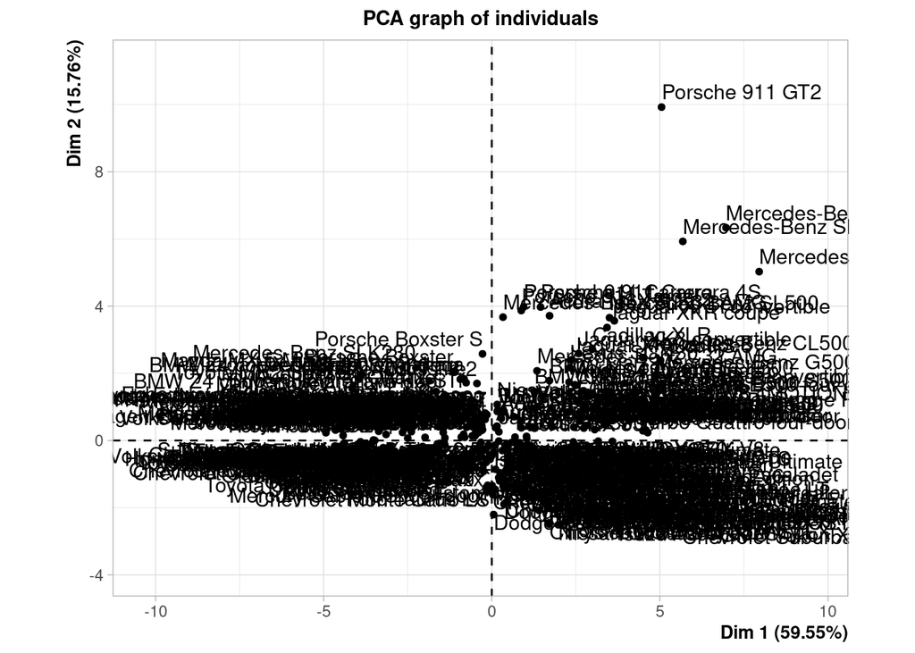

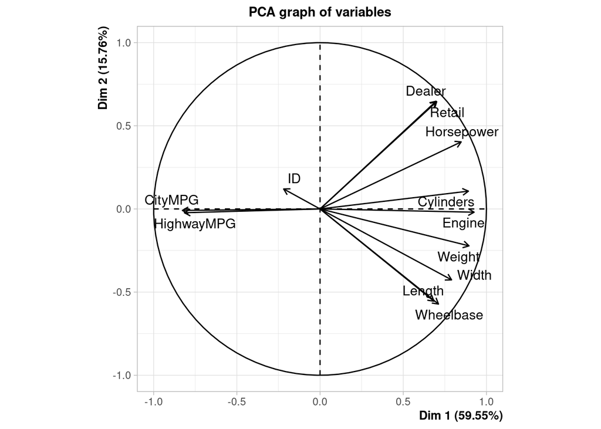

```r
summary(cars.PCA)
```

```
##
## Call:
## PCA(X = cars, scale.unit = TRUE)
##
##
## Eigenvalues
##                        Dim.1   Dim.2   Dim.3   Dim.4   Dim.5   Dim.6   Dim.7
## Variance               7.146   1.891   0.972   0.841   0.351   0.275   0.198
## % of var.             59.550  15.759   8.097   7.012   2.928   2.295   1.647
## Cumulative % of var.  59.550  75.309  83.406  90.418  93.346  95.641  97.288
##                        Dim.8   Dim.9  Dim.10  Dim.11  Dim.12
## Variance               0.140   0.083   0.065   0.036   0.001
## % of var.              1.168   0.693   0.543   0.302   0.006
## Cumulative % of var.  98.456  99.149  99.692  99.994 100.000
##
## Individuals (the 10 first)
##                              Dist    Dim.1    ctr   cos2    Dim.2    ctr   cos2
## Acura 3.5 RL             |  2.558 |  1.704  0.105  0.444 | -0.582  0.046  0.052
## Acura 3.5 RL Navigation  |  2.607 |  1.771  0.113  0.461 | -0.473  0.031  0.033
## Acura MDX                |  3.058 |  2.040  0.150  0.445 | -0.539  0.040  0.031
## Acura NSX S              |  4.770 |  1.719  0.107  0.130 |  3.714  1.885  0.606
## Acura RSX                |  3.280 | -2.509  0.228  0.585 |  0.483  0.032  0.022
## Acura TL                 |  1.892 |  0.578  0.012  0.093 | -0.064  0.001  0.001
## Acura TSX                |  2.433 | -1.397  0.071  0.330 | -0.128  0.002  0.003
## Audi A4 1.8T             |  2.798 | -1.894  0.130  0.458 | -0.221  0.007  0.006
## Audi A4 1.8T convertible |  2.681 | -1.395  0.070  0.271 |  0.079  0.001  0.001
## Audi A4 3.0 convertible  |  1.930 |  0.284  0.003  0.022 |  0.658  0.059  0.116
##                             Dim.3    ctr   cos2
## Acura 3.5 RL             | -1.499  0.597  0.343 |
## Acura 3.5 RL Navigation  | -1.502  0.600  0.332 |
## Acura MDX                | -1.251  0.416  0.167 |
## Acura NSX S              | -1.836  0.896  0.148 |
## Acura RSX                | -1.814  0.875  0.306 |
## Acura TL                 | -1.647  0.722  0.758 |
## Acura TSX                | -1.618  0.696  0.442 |
## Audi A4 1.8T             | -1.640  0.715  0.344 |
## Audi A4 1.8T convertible | -1.616  0.694  0.363 |
## Audi A4 3.0 convertible  | -1.568  0.654  0.660 |
##
## Variables (the 10 first)
##                             Dim.1    ctr   cos2    Dim.2    ctr   cos2    Dim.3
## Retail                   |  0.701  6.875  0.491 |  0.645 22.002  0.416 | -0.059
## Dealer                   |  0.697  6.798  0.486 |  0.648 22.175  0.419 | -0.055
## Engine                   |  0.926 11.994  0.857 | -0.020  0.020  0.000 | -0.030
## Cylinders                |  0.892 11.124  0.795 |  0.107  0.607  0.011 | -0.065
## Horsepower               |  0.848 10.065  0.719 |  0.403  8.602  0.163 | -0.027
## CityMPG                  | -0.827  9.576  0.684 | -0.009  0.004  0.000 | -0.140
## HighwayMPG               | -0.815  9.301  0.665 | -0.023  0.027  0.001 | -0.204
## Weight                   |  0.895 11.212  0.801 | -0.222  2.606  0.049 |  0.121
## Wheelbase                |  0.712  7.086  0.506 | -0.572 17.296  0.327 | -0.025
## Length                   |  0.685  6.559  0.469 | -0.555 16.285  0.308 |  0.015
##                             ctr   cos2
## Retail                    0.363  0.004 |
## Dealer                    0.314  0.003 |
## Engine                    0.093  0.001 |
## Cylinders                 0.441  0.004 |
## Horsepower                0.075  0.001 |
## CityMPG                   2.018  0.020 |
## HighwayMPG                4.296  0.042 |
## Weight                    1.497  0.015 |
## Wheelbase                 0.063  0.001 |
## Length                    0.024  0.000 |
```

summary() provides us with all the information we were able to gather in the previous section.

We note that the signs of the coefficients of the vectors in the base are different, but the whole remains coherent, as those that were negative are positive and vice versa. Thus, the directions remain the same, only the direction of the vectors changes, which is of no importance for our analyses.

If we leave aside the signs of the coefficients and look at their absolute values, the values of the basis vectors are different between the functions $PCA()$ and $prcomp()$, since the latter returns the eigenvectors of norm $1$, and $PCA()$ these same eigenvectors multiplied by the root of the associated eigenvalues. If we take the first eigenvector and multiply its components by $\sqrt{7.105} \approx 2.6655$ , we get $0.2637504 \times 2.6655 = 0.7030266912$, $0.2623186 \times 2.6655 = 0.6992102283$, … . These are called “loadings”. Here again, we’re just talking about vector dilation, which doesn’t change our interpretations.

As proof, let’s reanalyze the principal components:

For the 1st component : negatively correlated with CityMPG and HighWayMPG and positively correlated with all other variables. Once again, the first component separates cars with low fuel consumption, low cost and/or small engine size from cars with high cost, large engine size and/or powerful engine. The same two groups are formed.

In the end, the analysis is the same.

```r
dimdesc(cars.PCA)
```

```
## $Dim.1
##
## Link between the variable and the continuous variables (R-square)
## =================================================================================
##            correlation       p.value
## Engine       0.9257934 9.767231e-165
## Weight       0.8951142 3.886263e-137
## Cylinders    0.8915914 1.575898e-134
## Horsepower   0.8480690 3.091986e-108
## Width        0.7903624  6.086508e-84
## Wheelbase    0.7115729  5.510433e-61
## Retail       0.7009360  1.795230e-58
## Dealer       0.6969678  1.456449e-57
## Length       0.6846430  7.842174e-55
## ID          -0.2186389  1.425879e-05
## HighwayMPG  -0.8152439  2.303240e-93
## CityMPG     -0.8272157  2.018007e-98
##
## $Dim.2
##
## Link between the variable and the continuous variables (R-square)
## =================================================================================
##            correlation      p.value
## Dealer       0.6475727 2.236511e-47
## Retail       0.6450373 6.634056e-47
## Horsepower   0.4033230 1.430000e-16
## ID           0.1200666 1.813252e-02
## Cylinders    0.1071017 3.518826e-02
## Weight      -0.2219760 1.044421e-05
## Width       -0.4264047 1.575799e-18
## Length      -0.5549470 1.220944e-32
## Wheelbase   -0.5719065 5.403230e-35
##
## $Dim.3
##
## Link between the variable and the continuous variables (R-square)
## =================================================================================
##            correlation       p.value
## ID           0.9392480 6.931081e-181
## Weight       0.1206178  1.760475e-02
## CityMPG     -0.1400452  5.785183e-03
## HighwayMPG  -0.2043058  5.144722e-05
```

On the other hand, $dimdesc()$ confirms the results and interpretations from $summary()$, since the p-values of the two coefficients of the two principal component director vectors are very low, even negligible. We are therefore confident in their value.

# Localization of data respect to PC1 and PC2

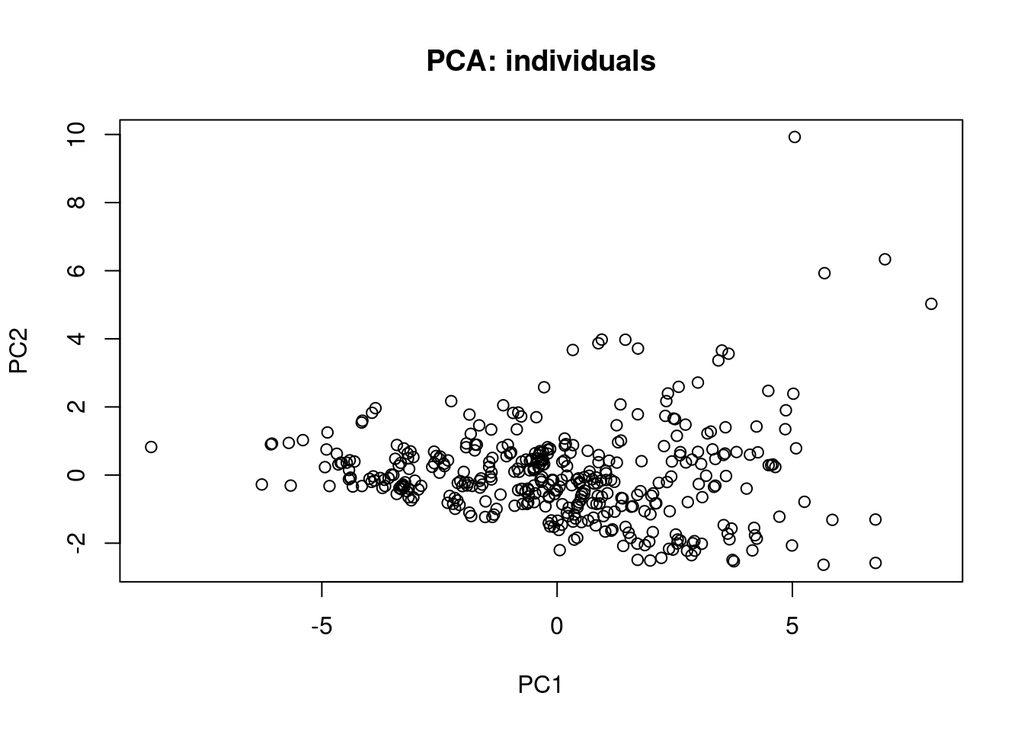

```r
plot(cars.PCA$ind$coord[,1], cars.PCA$ind$coord[,2], xlab=paste0("PC1"), ylab=paste0("PC2"), main="PCA: individuals")
```

The graph shows the distribution of individuals defined by the first two components. Each point represents a car model. It can be seen that there is some clustering of car models in certain areas of the graph.

We can see that there are many cars with a negative PC1 component, with a slight advantage for those with a positive PC2 component. So there’s a big market for city cars and family cars.

# Analysis

```r
my3car <- c("Audi RS 6", "Ford Expedition 4.6 XLT", "Nissan Sentra 1.8")
cars.PCA$ind$contrib[my3car,]
```

```
##                             Dim.1      Dim.2       Dim.3      Dim.4      Dim.5
## Audi RS 6               0.9113623 0.77902318 0.623747227 0.11617997 0.25417739
## Ford Expedition 4.6 XLT 0.6227849 0.66901962 0.004306695 0.02497727 0.04107222
## Nissan Sentra 1.8       0.5748006 0.00172736 0.029943254 0.08517990 0.02029285
```

```r
cars[my3car,]
```

```
##                          Retail   Dealer Engine Cylinders Horsepower  CityMPG
## Audi RS 6               79947.0 72214.07    4.2         8        450  6.37710
## Ford Expedition 4.6 XLT 32659.2 28792.26    4.6         8        232  6.37710
## Nissan Sentra 1.8       12039.3 11533.72    1.8         4        126 11.90392
##                         HighwayMPG   Weight Wheelbase Length  Width  ID
## Audi RS 6                  9.35308 1825.255  49.44156 485.14 198.12  23
## Ford Expedition 4.6 XLT    8.07766 2267.961  53.97748 523.24 200.66 113
## Nissan Sentra 1.8         14.87990 1139.877  45.35923 452.12 170.18 280
```

For Audi RS 6 and Ford Expedition 4.6 XLT, their PC1 and PC2 components are positive. The value of their PC1 component is of the same order of magnitude as their PC2 component. Both cars are high-consumption, high-cylinder, high-capacity engines. However, the value of the first PC2 component of the Audi RS 6 is greater than that of the Ford Expedition 4.6 XLT, so the Audi RS 6 is more expensive than the Ford Expedition 4.6 XLT but has better fuel consumption than the latter. Selecting the $cars$ data, we can see that this is true (the Audi RS 6’s fuel consumption is higher on freeways, while city consumption is similar).

With a larger PC2 component for the Audi RS 6 than for the Ford Expedition 4.6 XLT, the Audi must be closer to a sports or luxury car, and the Ford to a large car. The Audi RS 6 is classified as a luxury car by Wikipedia, and it’s also a sports (performance-oriented) car. The Ford is indeed a large vehicle.